# Expected Pressure: An Evaluation of Individual and Team Performances in Pressing Situations

Natalie Rayce, David Almona

## Introduction: What is a press?

**Pressing** is a defensive tactic where players apply coordinated pressure on the opponent with the ball to force mistakes, win back possession, and quickly transition to attack

## Data

- **Dataset:** 521 matches in the MLS 2023 season
- **Three data modalities:**
  - Match information: home team, away team, pitch and referee information, ect.
  - Event data: on‑ball and off-ball activities—ex: passes, shots, tackles, recoveries, runs , turnovers , and goals—along with timestamp, location coordinates and player name
  - Tracking data: identity, location and movement of all 22 players and the ball, across the full 90 minutes(10 Hz)
- **Official data** from SkillCorner, which uses computer vision and machine learning to extract data from video broadcast

## Methods

- We standardized the tracking data so that home team always attacks left-to-right
- We pre defined the parameters to identify pressing sequences and - extracted data from the tracking and events files.
- Measure effectiveness through a forced turnover 5s after pressing sequence begins
- We accounted for spatio-temporal variables like speed, distance, positioning.
- We analyzed just the first 10 games which had 4785 identified pressing sequences

- For modeling, we used Extreme Gradient Boosting (XGBoost), a machine learning algorithm that uses multiple decision trees to model complex relationships.
- 10-fold cross-validation

## Discussion

- Limitations:
  - Inaccuracy in SkillCorner Data
  - Individual Player Skill and Tactical Tendencies not considered in the mode
- We assumed a circular pressure zone rather than an elliptical (or oval) pressure zone

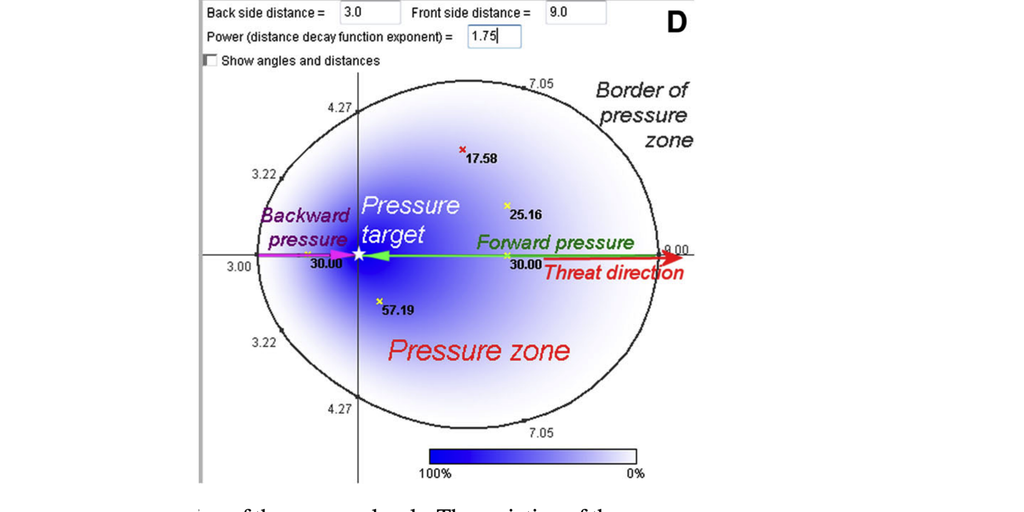

## Plan of Action

1. Now that we have an XGBoost model, we plan to compare it with other models, e.g logistic, random forest, lightGBM
2. Compare the expected pressure difference from individuals and teams on a scatterplot

[figure not shown]